# Introduction to R

## Topics of this lecture

1. Introduction to R and RStudio
   - Working with packages
   - Getting help in R
2. Reproducible data analysis with R Markdown
3. Organise your work with R Projects

## Introduction to R and RStudio

## What is R

- R is a language and environment for statistical computing and for graphics
- Based on the object-oriented language S (1975)
- 100% free software
- Managed by the R Foundation for Statistical Computing, Vienna, Austria.
- Community-driven:
  - More than 10.000 packages developed by community
  - New packages are constantly being developed
  - New features are constantly being added to existing packages

## Fun fact about R:

Every version of `R` that is released is named after a topic in a Peanuts comic. The `R` version 4.3.3 (2024-02-29) is called “Angel Food Cake”.

R version

Charlie Brown cartoon

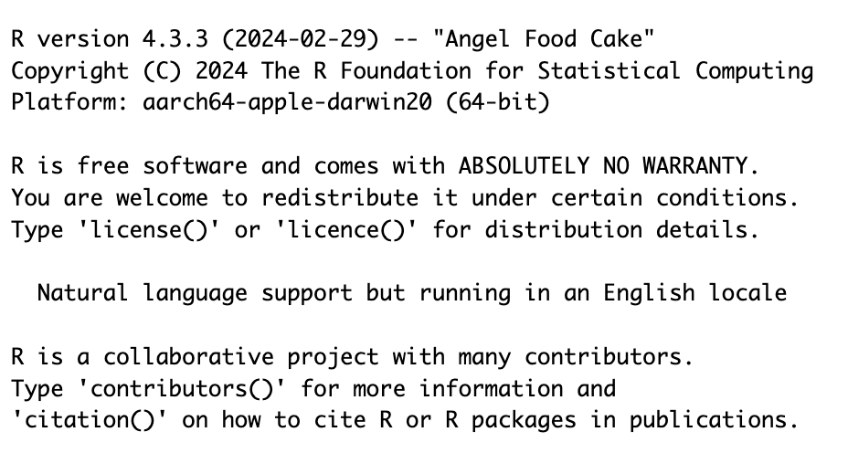

[figure not shown]

## What is RStudio?

- RStudio is an Integrated Development Environment (IDE)
- RStudio has all functionality in one place and makes working with R much easier.
- Use RStudio to:
  - Edit scripts, Run scripts
  - Manage your code with highlighting
  - Navigate files, organize projects
  - Utilize version control (e.g. Github)
  - View static and interactive graphics
  - Create different file types (RMarkdown, Shiny apps)
  - Work with different languages (Python, JavaScript, C++, etc.)

## The 4 panes in RStudio

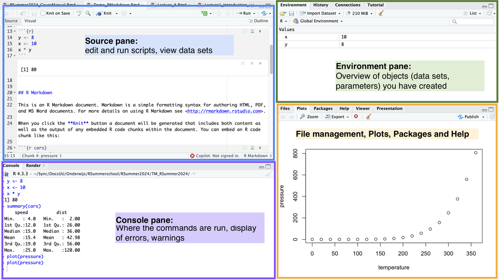

## Working with R packages

## R Packages: base installation

- When you start RStudio and R only the base packages are activated: the basic installation with basic functionality.
- There are almost 20.000 packages that have been developed by R users all over the world. See the [Comprehensive R Archive Network (CRAN)](https://cran.r-project.org/web/packages/)
- Not efficient to have all these packages installed every time you use R. Install only the packages you want to use.

## See which packages are active

- Use `sessionInfo()` to see which packages are active.
- This is how the basic installation looks like:

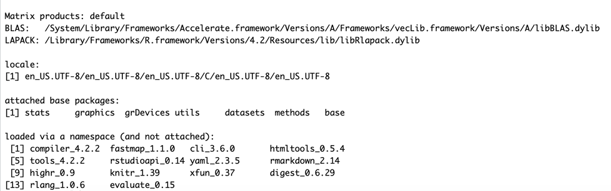

## Overview of installed packages

An overview of the packages you have installed, see the tab “Packages” in the output pane:

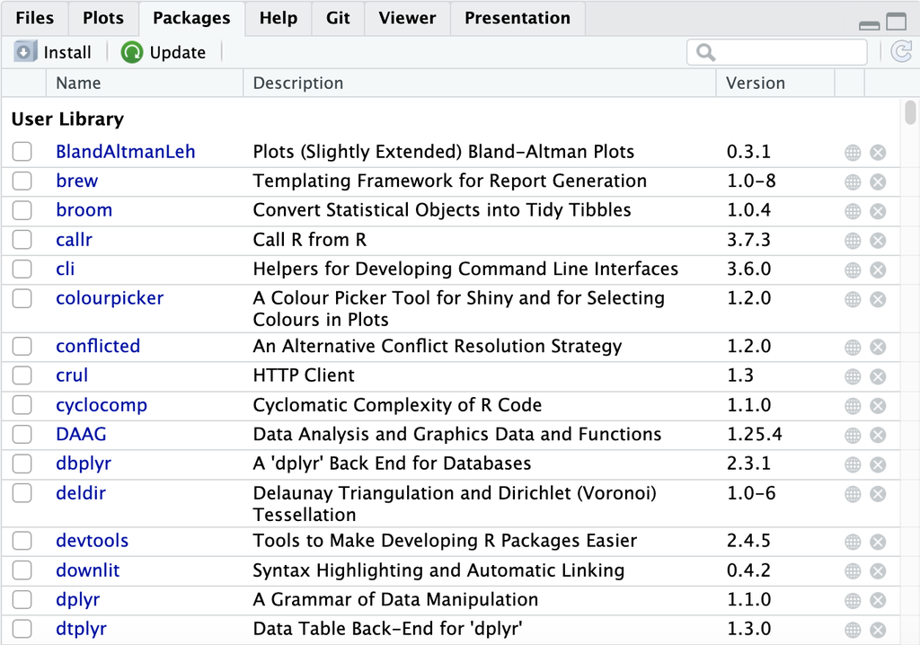

## How to work with packages

Packages are like apps on your mobile phone.

- When you want to use a package for the first time, you have to **install** the package.
- Each time you want to use the package, you have to **load** (activate) it.

## Opening and closing packages

To **load** a package (similar to opening an app on your phone), use the following code:

```r
library(ggplot2)
```

To **close** a package (similar to closing an app on your phone), use:

```r
detach(ggplot2)
```

## Reproducible data analysis with R Markdown

## Why work with R Markdown?

The need to *combine code and text* and to document all the steps to make **reproducible** (scientific) reports of data analyses.

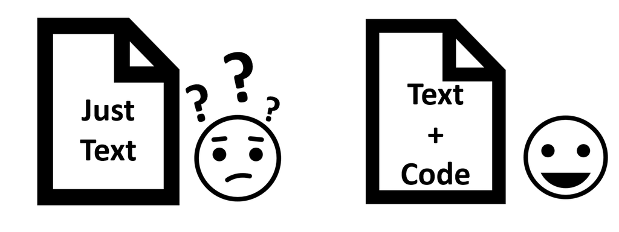

To **collaborate** effectively and use **version control** with Github.

[figure not shown]

[*Images source*](https://zsmith27.github.io/rmarkdown_crash-course/introduction.html)

## Why work with R Markdown?

It is **efficient**. Generate and update reports in all kinds of formats:

[figure not shown]

[*Source:* What is R Markdown? Video RStudio](https://vimeo.com/178485416)

## Demo RStudio and RMarkdown

## Writing text in R Markdown

See the [R Markdown Cheat Sheet](https://posit.co/wp-content/uploads/2022/10/rmarkdown-1.pdf) for a complete list of options.

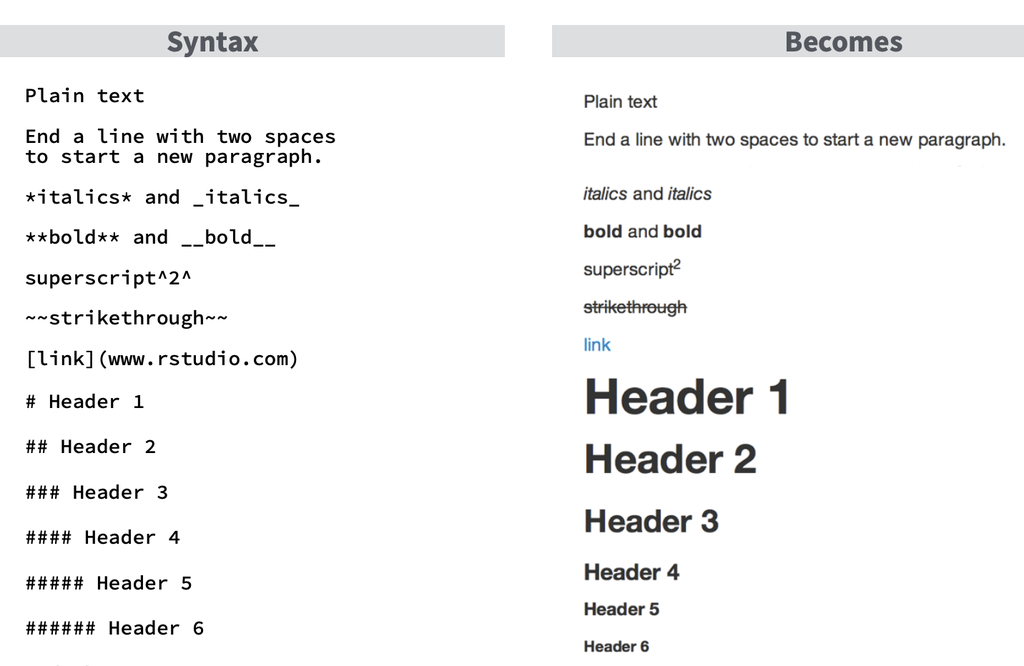

## Writing text in R Markdown

[figure not shown]

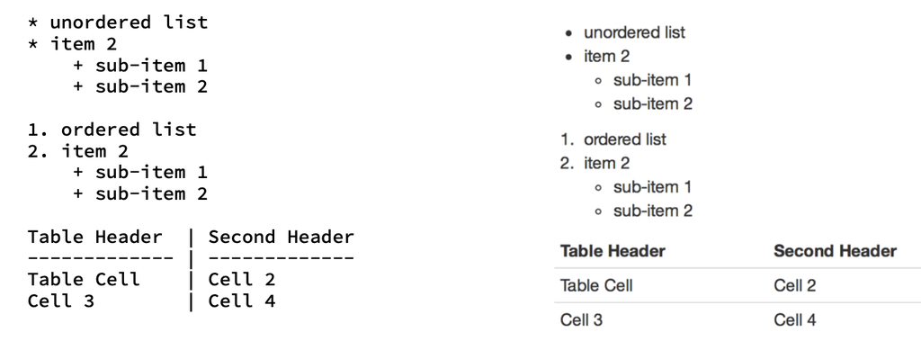

## Writing code in R Markdown

Code chunks start with `{r }` (for R code). You can give code chunks names (here cars).

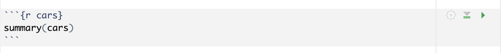

This is how the result looks like in the rendered html document. Display of both R code and results:

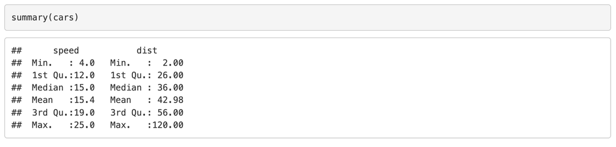

## Code chunk options

You can choose to hide the R code with `echo=FALSE` in the chunk header:

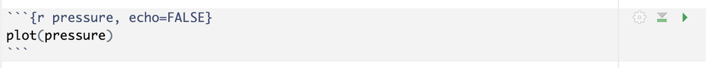

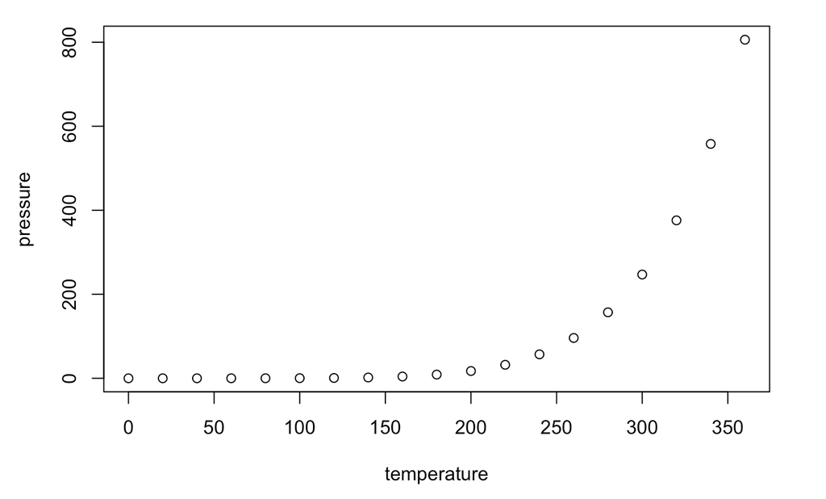

See the [R Markdown Cheat Sheet](https://posit.co/wp-content/uploads/2022/10/rmarkdown-1.pdf) for a complete list of knitr chunk options.

## Getting help with R Markdown

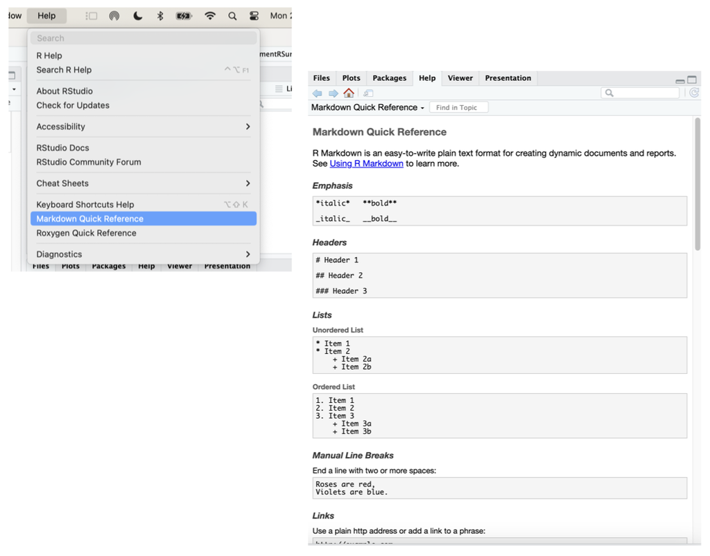

## R Studio Projects

## Use RStudio Projects

Every time you start a new (data analysis) project, make it a habit to create a new **RStudio Project**.

**Because you want your project to work:**

- not only now, but also in a few years;
- when the folder and file paths have changed;
- when collaborators want to run your code on their computer.

**RStudio Projects** create a convention that guarantees that the project can be moved around on your computer or onto other computers and will still “just work”. It creates relative paths (no more broken paths!).

## Example: Data analysis RStudio project

All data, scripts, and output should be stored within the project directory.

Every time you want to work on this project: open the project by clicking the `.Rproj` file.

[figure not shown]

## Lab 1a

## Lab 1a: learn to work with R Projects and R Markdown

- Open the course manual
- Click on the tab “Monday”
- Go to **Course materials** and click on **Lectures and Labs Monday**, which starts the download of a folder with:
  - A html file of the lecture: “1a_Lecture.html”
  - A html file of the lab: “1a_Lab.html”

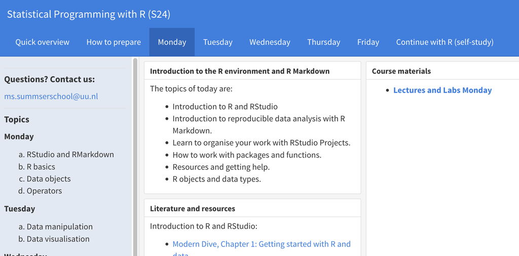